# Лабораторная работа №1 — Андреус А. А.

Национальный исследовательский ядерный университет «МИФИ»

Дисциплина «Статистические исследования»

ЛАБОРАТОРНАЯ РАБОТА № 1

«Обработка анкет и описательная статистика в R: инфляционные ожидания и потребительские настроения»

Андреус Аглая Ашотовна  
Группа Б24-902 · Вариант 85

Москва · 2026

# 1. Цель и проверка данных

Цель — обработать анкеты в R, рассчитать инфляционные медианы, доходы и потребительские индексы, сопоставить учебный сентябрь с опубликованным августом 2026 года.

Исходник: Andreus_Aglaya_Ashotovna_B24-902_Var85.xlsx; 2000 анкет, 21 столбец. Нет исходной категории дохода на человека; для групповых сравнений использованы пять квантильных групп расчетного дохода. Исходный XLSX не изменялся. Результаты проверок и пригодность показателей — в таблицах 1–2.

Таблица 1. Проверка структуры и значений

| Проверка | Число |
| --- | --- |
| Отсутствующие столбцы (единица — столбцы) | 1 |
| Отсутствующая характеристика дохода (затронуто анкет) | 2000 |
| Пустой ID | 0 |
| Строки с повторяющимся непустым ID | 0 |
| Недопустимая категория хотя бы в одном поле (строки) | 0 |
| Q12: пропуск, нечисловое, нецелое или неположительное | 0 |
| Q4 пусто, хотя поле требуется | 0 |
| Q4 заполнено, хотя поле не задавалось | 0 |
| Q6 пусто, хотя поле требуется | 0 |
| Q6 заполнено, хотя поле не задавалось | 0 |
| Тип предприятия работодателя пусто, хотя поле требуется | 0 |
| Тип предприятия работодателя заполнено, хотя поле не задавалось | 0 |

Таблица 2. Пригодные ответы N, технические и структурные пропуски

| Показатель | N | Тех. | Стр. | Недоп. |
| --- | --- | --- | --- | --- |
| Пол | 2000 | 0 | 0 | 0 |
| Возраст | 2000 | 0 | 0 | 0 |
| Образование | 2000 | 0 | 0 | 0 |
| Род занятий | 2000 | 0 | 0 | 0 |
| Тип предприятия работодателя | 1192 | 0 | 0 | 0 |
| Тип расселения | 2000 | 0 | 0 | 0 |
| Самооценка материального положения семьи | 2000 | 0 | 0 | 0 |
| Q1 | 2000 | 0 | 0 | 0 |
| Q2 | 2000 | 0 | 0 | 0 |
| Q3 | 2000 | 0 | 0 | 0 |
| Q4 | 1872 | 0 | 128 | 0 |
| Q5 | 2000 | 0 | 0 | 0 |
| Q6 | 1669 | 0 | 331 | 0 |
| Q7 | 2000 | 0 | 0 | 0 |
| Q8 | 2000 | 0 | 0 | 0 |
| Q9 | 2000 | 0 | 0 | 0 |
| Q10 | 2000 | 0 | 0 | 0 |
| Q11 | 2000 | 0 | 0 | 0 |
| Q13 | 2000 | 0 | 0 | 0 |
| Q12 | 2000 | — | — | — |
| infl_obs | 1444 | — | — | — |
| infl_exp | 1282 | — | — | — |
| Доход на человека | 1630 | — | — | — |

В расчетах испорченное поле не исключает анкету целиком. «Затрудняюсь» — допустимый ответ; пустота незаданного вопроса — структурный пропуск.

# 2. Частоты и доли ответов

$$p_j=\frac{n_j}{N}\cdot100\%.$$

Для вопросов всем N — число допустимых ответов; для Q4/Q6 — число респондентов, которым вопрос задавался. Технические пропуски показаны отдельно. Все допустимые категории сохранены; доли округлены до целого процента.

Таблица 3. Пол; N = 2000

| Категория | n | Доля, % |
| --- | --- | --- |
| женщины | 1096 | 55 |
| мужчины | 904 | 45 |

Таблица 4. Возраст; N = 2000

| Категория | n | Доля, % |
| --- | --- | --- |
| 18–30 лет | 402 | 20 |
| 31–45 лет | 529 | 26 |
| 46–60 лет | 573 | 29 |
| старше 60 лет | 496 | 25 |

Таблица 5. Образование; N = 2000

| Категория | n | Доля, % |
| --- | --- | --- |
| высшее | 660 | 33 |
| ниже среднего | 78 | 4 |
| среднее общее | 511 | 26 |
| среднее специальное | 751 | 38 |

Таблица 6. Род занятий; N = 2000

| Категория | n | Доля, % |
| --- | --- | --- |
| не работают и не ищут работу | 88 | 4 |
| не работают, но ищут работу | 80 | 4 |
| неработающие пенсионеры | 470 | 24 |
| работающие по найму | 1192 | 60 |
| самозанятые | 170 | 8 |

Таблица 7. Тип предприятия работодателя; N = 1192

| Категория | n | Доля, % |
| --- | --- | --- |
| государственное, с госучастием | 506 | 42 |
| частное, НКО | 686 | 58 |

Таблица 8. Тип расселения; N = 2000

| Категория | n | Доля, % |
| --- | --- | --- |
| Городское | 1423 | 71 |
| Сельское | 577 | 29 |

Таблица 9. Самооценка материального положения семьи; N = 2000

| Категория | n | Доля, % |
| --- | --- | --- |
| денег не хватает на питание | 128 | 6 |
| на питание хватает, на одежду – нет | 361 | 18 |
| на одежду хватает, на крупную бытовую технику – нет | 732 | 37 |
| на бытовую технику хватает, на автомобиль – нет | 456 | 23 |
| на автомобиль хватает | 323 | 16 |

Таблица 10. Q1/Q2: цены за прошлый и следующий месяц; N = 2000

| Ответ | n Q1 | % Q1 | n Q2 | % Q2 |
| --- | --- | --- | --- | --- |
| Очень сильно | 921 | 46 | 396 | 20 |
| Умеренно | 726 | 36 | 888 | 44 |
| Незначительно | 169 | 8 | 297 | 15 |
| Без изменения | 83 | 4 | 189 | 9 |
| Снижение | 6 | 0 | 8 | 0 |
| Затрудняюсь | 95 | 5 | 222 | 11 |

Таблица 11. Q3/Q5: направление изменения цен за прошлый и следующий год; N = 2000

| Ответ | n Q3 | % Q3 | n Q5 | % Q5 |
| --- | --- | --- | --- | --- |
| Быстрее | 1113 | 56 | 582 | 29 |
| Так же | 650 | 32 | 967 | 48 |
| Медленнее | 109 | 5 | 120 | 6 |
| Без изменения | 19 | 1 | 46 | 2 |
| Снижение | 0 | 0 | 15 | 1 |
| Затрудняюсь | 109 | 5 | 270 | 14 |

Таблица 12. Q4/Q6: интервалы роста; N4 = 1872, N6 = 1669

| Ответ | n Q4 | % Q4 | n Q6 | % Q6 |
| --- | --- | --- | --- | --- |
| на 2% и менее | 28 | 1 | 39 | 2 |
| на 3–5% | 164 | 9 | 124 | 7 |
| на 6–8% | 130 | 7 | 141 | 8 |
| на 9–12% | 261 | 14 | 231 | 14 |
| на 13–16% | 178 | 10 | 130 | 8 |
| на 17–20% | 231 | 12 | 172 | 10 |
| на 21–25% | 109 | 6 | 103 | 6 |
| на 26–30% | 112 | 6 | 107 | 6 |
| на 31–40% | 78 | 4 | 60 | 4 |
| на 41–50% | 87 | 5 | 65 | 4 |
| на 51% и более | 47 | 3 | 49 | 3 |
| затрудняюсь ответить | 447 | 24 | 448 | 27 |

Таблица 13. Q7/Q8: материальное положение семьи; N = 2000

| Ответ | n Q7 | % Q7 | n Q8 | % Q8 |
| --- | --- | --- | --- | --- |
| Улучшение | 301 | 15 | 428 | 21 |
| Без изменений | 1025 | 51 | 751 | 38 |
| Ухудшение | 633 | 32 | 460 | 23 |
| Затрудняюсь ответить | 41 | 2 | 361 | 18 |

Таблица 14. Q9; N = 2000

| Категория | n | Доля, % |
| --- | --- | --- |
| хорошим | 247 | 12 |
| хорошим, но не во всём | 363 | 18 |
| не хорошим, но и не плохим | 481 | 24 |
| плохим, но не во всём | 242 | 12 |
| плохим | 432 | 22 |
| затрудняюсь ответить | 235 | 12 |

Таблица 15. Q10; N = 2000

| Категория | n | Доля, % |
| --- | --- | --- |
| хорошим | 388 | 19 |
| не хорошим, но и не плохим | 628 | 31 |
| плохим | 455 | 23 |
| затрудняюсь ответить | 529 | 26 |

Таблица 16. Q11; N = 2000

| Категория | n | Доля, % |
| --- | --- | --- |
| хорошее | 395 | 20 |
| не хорошее, но и не плохое | 803 | 40 |
| плохое | 611 | 31 |
| затрудняюсь ответить | 191 | 10 |

Таблица 17. Q13: доход семьи и его перекодировка; N = 2000

| Категория | n | Доля, % | Код H, руб. |
| --- | --- | --- | --- |
| 10 000 руб. и менее | 19 | 1 | 7000 |
| 10 001 – 15 000 руб. | 31 | 2 | 12500 |
| 15 001 – 20 000 руб. | 50 | 2 | 17500 |
| 20 001 – 25 000 руб. | 86 | 4 | 22500 |
| 25 001 – 30 000 руб. | 101 | 5 | 27500 |
| 30 001 – 40 000 руб. | 182 | 9 | 35000 |
| 40 001 – 50 000 руб. | 177 | 9 | 45000 |
| 50 001 – 60 000 руб. | 174 | 9 | 55000 |
| 60 001 – 70 000 руб. | 141 | 7 | 65000 |
| 70 001 – 80 000 руб. | 78 | 4 | 75000 |
| 80 001 – 90 000 руб. | 65 | 3 | 85000 |
| 90 001 – 100 000 руб. | 132 | 7 | 95000 |
| 100 001 – 120 000 руб. | 118 | 6 | 110000 |
| 120 001 – 150 000 руб. | 89 | 4 | 135000 |
| свыше 150 000 руб. | 187 | 9 | 200000 |
| не знаю, затрудняюсь ответить | 155 | 8 | Исключен |
| отказ от ответа | 215 | 11 | Исключен |

Таблица 18. Q4/Q6: доли от всей выборки, включая незаданный вопрос; N = 2000

| Ответ | n Q4 | % Q4 | n Q6 | % Q6 |
| --- | --- | --- | --- | --- |
| на 2% и менее | 28 | 1 | 39 | 2 |
| на 3–5% | 164 | 8 | 124 | 6 |
| на 6–8% | 130 | 6 | 141 | 7 |
| на 9–12% | 261 | 13 | 231 | 12 |
| на 13–16% | 178 | 9 | 130 | 6 |
| на 17–20% | 231 | 12 | 172 | 9 |
| на 21–25% | 109 | 5 | 103 | 5 |
| на 26–30% | 112 | 6 | 107 | 5 |
| на 31–40% | 78 | 4 | 60 | 3 |
| на 41–50% | 87 | 4 | 65 | 3 |
| на 51% и более | 47 | 2 | 49 | 2 |
| затрудняюсь ответить | 447 | 22 | 448 | 22 |
| Технический пропуск | 0 | 0 | 0 | 0 |
| Недопустимый ответ | 0 | 0 | 0 | 0 |
| Вопрос не задавался | 128 | 6 | 331 | 17 |
| Условие задавания неизвестно | 0 | 0 | 0 | 0 |

Таблица 19. Q12: размер семьи

| N | Минимум | Максимум | Среднее | Медиана |
| --- | --- | --- | --- | --- |
| 2000 | 1 | 6 | 2.7 | 2 |

Таблица 20. Q12: частоты размеров семьи

| Членов семьи | n | Доля, % |
| --- | --- | --- |
| 1 | 384 | 19 |
| 2 | 664 | 33 |
| 3 | 471 | 24 |
| 4 | 283 | 14 |
| 5 | 140 | 7 |
| 6 | 58 | 3 |

# 3. Годовая инфляция и медианы

`infl_obs` получена из Q3/Q4, `infl_exp` — из Q5/Q6. Снижение → −5; без изменения → 0; рост → код интервала; неопределенный ответ → NA. «Рост медленнее» остается ростом. Q1/Q2 в годовые проценты не переводятся. В таблице ниже 1 — наблюдаемая, 2 — ожидаемая инфляция.

Таблица 21. Перекодировка, частоты n и накопленные частоты F

| Категория | Код | n1 | F1 | n2 | F2 |
| --- | --- | --- | --- | --- | --- |
| Снижение (условный код) | -5.0 | 0 | 0 | 15 | 15 |
| Без изменения | 0.0 | 19 | 19 | 46 | 61 |
| на 2% и менее | 1.0 | 28 | 47 | 39 | 100 |
| на 3–5% | 4.0 | 164 | 211 | 124 | 224 |
| на 6–8% | 7.0 | 130 | 341 | 141 | 365 |
| на 9–12% | 10.5 | 261 | 602 | 231 | 596 |
| на 13–16% | 14.5 | 178 | 780 | 130 | 726 |
| на 17–20% | 18.5 | 231 | 1011 | 172 | 898 |
| на 21–25% | 23.0 | 109 | 1120 | 103 | 1001 |
| на 26–30% | 28.0 | 112 | 1232 | 107 | 1108 |
| на 31–40% | 35.5 | 78 | 1310 | 60 | 1168 |
| на 41–50% | 45.5 | 87 | 1397 | 65 | 1233 |
| на 51% и более | 75.0 | 47 | 1444 | 49 | 1282 |

Таблица 22. Медианы и квартили, % годовых

| Показатель | N | Q1 | Медиана | Q3 | Уточн. |
| --- | --- | --- | --- | --- | --- |
| Наблюдаемая | 1444 | 10.5 | 14.5 | 23 | 15.2 |
| Ожидаемая | 1282 | 7.0 | 14.5 | 23 | 13.9 |

$$\tilde{x}_{0.5}=L+h\frac{N/2-F_{prev}}{f}.$$

**Наблюдаемая.** Медианная категория — на 13–16%; N = 1444, N/2 = 722,0, L = 12,5, h = 4,0, F_prev = 602, f = 178. Подстановка: $\tilde{x}_{0.5} = 12,5 + 4,0 \cdot (722,0 - 602)/178 = 15,1966$ % годовых.

**Ожидаемая.** Медианная категория — на 13–16%; N = 1282, N/2 = 641,0, L = 12,5, h = 4,0, F_prev = 596, f = 130. Подстановка: $\tilde{x}_{0.5} = 12,5 + 4,0 \cdot (641,0 - 596)/130 = 13,8846$ % годовых.

L — нижняя непрерывная граница; h — ширина; f — частота медианного интервала; F_prev — частота до него. Для 13–16%: [12,5; 16,5), h = 4. Для кодов −5, 0, 1, 75 интерполяция не определена: используется условный код. Частоты и медианы показаны на рисунке 3.

# 4. Среднедушевой доход

$$y_i=\frac{H_i}{m_i},\qquad IQR=Q_{0.75}-Q_{0.25}.$$

H_i — код Q13, m_i — положительное целое Q12. Крайние коды дохода — 7000 и 200 000 руб.; неопределенные ответы исключены. Интервалы ниже имеют вид [a; b), шаг 5000 руб. (границы в тыс. руб.). Гистограмма — рисунок 4.

Таблица 23. Доход на человека, руб. в месяц

| Показатель | Значение |
| --- | --- |
| N | 1630.0 |
| Среднее | 36633.4 |
| Медиана | 27500.0 |
| Первый квартиль | 15000.0 |
| Третий квартиль | 47500.0 |
| IQR | 32500.0 |
| Уточненная медиана | 26417.3 |

Таблица 24. Интервальный ряд дохода: частоты n и накопленные F

| Доход, тыс. | n | F | Доход, тыс. | n | F |
| --- | --- | --- | --- | --- | --- |
| 0–5 | 48 | 48 | 105–110 | 0 | 1570 |
| 5–10 | 175 | 223 | 110–115 | 20 | 1590 |
| 10–15 | 184 | 407 | 115–120 | 0 | 1590 |
| 15–20 | 195 | 602 | 120–125 | 0 | 1590 |
| 20–25 | 177 | 779 | 125–130 | 0 | 1590 |
| 25–30 | 127 | 906 | 130–135 | 0 | 1590 |
| 30–35 | 99 | 1005 | 135–140 | 14 | 1604 |
| 35–40 | 104 | 1109 | 140–145 | 0 | 1604 |
| 40–45 | 42 | 1151 | 145–150 | 0 | 1604 |
| 45–50 | 97 | 1248 | 150–155 | 0 | 1604 |
| 50–55 | 42 | 1290 | 155–160 | 0 | 1604 |
| 55–60 | 76 | 1366 | 160–165 | 0 | 1604 |
| 60–65 | 0 | 1366 | 165–170 | 0 | 1604 |
| 65–70 | 99 | 1465 | 170–175 | 0 | 1604 |
| 70–75 | 0 | 1465 | 175–180 | 0 | 1604 |
| 75–80 | 14 | 1479 | 180–185 | 0 | 1604 |
| 80–85 | 0 | 1479 | 185–190 | 0 | 1604 |
| 85–90 | 11 | 1490 | 190–195 | 0 | 1604 |
| 90–95 | 0 | 1490 | 195–200 | 0 | 1604 |
| 95–100 | 23 | 1513 | 200–205 | 26 | 1630 |
| 100–105 | 57 | 1570 |  |  |  |

Медианный интервал: [25000; 30000) руб.

$$\tilde{y}_{0.5}=25000+5000\frac{815-779}{127}=26417,3\text{ руб.}$$

Опубликованная августовская медиана — 27 300 руб. (инФОМ, с. 20). Прямое сравнение ограничено различиями методики и выборки.

# 5. Потребительские индексы

$$P_j=100\frac{n_j^+}{N_j},\quad M_j=100\frac{n_j^-}{N_j},\quad I_j=100+P_j-M_j.$$

В знаменателе учитывается «затрудняюсь»; технические пропуски исключены. Для Q9 «хорошим, но не во всём» — положительный ответ, «плохим, но не во всём» — отрицательный. Названия I1–I5 — на рисунке 5; P и M — проценты, индексы — пункты.

Таблица 25. Частные индексы и основания расчета

| Индекс | Q | n+ | n− | N | P, % | M, % | Знач. |
| --- | --- | --- | --- | --- | --- | --- | --- |
| I1 | Q7 | 301 | 633 | 2000 | 15.1 | 31.6 | 83.4 |
| I2 | Q8 | 428 | 460 | 2000 | 21.4 | 23.0 | 98.4 |
| I3 | Q9 | 610 | 674 | 2000 | 30.5 | 33.7 | 96.8 |
| I4 | Q10 | 388 | 455 | 2000 | 19.4 | 22.8 | 96.7 |
| I5 | Q11 | 395 | 611 | 2000 | 19.8 | 30.6 | 89.2 |

Таблица 26. Составные индексы, пункты

| Индекс | Значение |
| --- | --- |
| ИТС | 86.3 |
| ИПО | 97.3 |
| ИПН | 92.9 |

$$ИТС=\frac{I_1+I_5}{2},\qquad ИПО=\frac{I_2+I_3+I_4}{3},$$

$$ИПН=\frac{I_1+I_2+I_3+I_4+I_5}{5}=\frac{2ИТС+3ИПО}{5}.$$

Проверка двух формул: разность 0,0000000000 пункта. Уровень 100 — равенство положительных и отрицательных долей.

# 6. Групповые сравнения

Г1–Г5 — квантильные группы расчетного дохода: первая включает обе границы, остальные имеют вид (a; b]. Это учебная замена отсутствующей характеристики. N — число анкет, N инф. — число пригодных `infl_exp`. Условный порог малочисленности — 30 ответов; все группы его превышают.

Таблица 27. Границы дохода, основания и обычная медиана ожидаемой инфляции

| Группа | Доход, руб. | N | N инф. | Медиана, % |
| --- | --- | --- | --- | --- |
| Г1 | [1400,0; 11666,7] | 332 | 197 | 10.5 |
| Г2 | (11666,7; 22000,0] | 325 | 196 | 14.5 |
| Г3 | (22000,0; 32500,0] | 326 | 214 | 14.5 |
| Г4 | (32500,0; 55000,0] | 383 | 265 | 14.5 |
| Г5 | (55000,0; 200000,0] | 264 | 173 | 14.5 |

Таблица 28. Доли Q5 внутри групп дохода, %; основания — N групп

| Ответ Q5 | Г1, % | Г2, % | Г3, % | Г4, % | Г5, % |
| --- | --- | --- | --- | --- | --- |
| Быстрее | 29 | 28 | 33 | 27 | 31 |
| Так же | 48 | 49 | 46 | 51 | 48 |
| Медленнее | 6 | 6 | 5 | 7 | 7 |
| Без изменения | 3 | 2 | 2 | 2 | 1 |
| Снижение | 1 | 0 | 1 | 0 | 1 |
| Затрудняюсь | 13 | 16 | 13 | 11 | 11 |

Таблица 29. ИПН мужчин и женщин, пункты

| Пол | N | ИПН |
| --- | --- | --- |
| мужчины | 904 | 93.3 |
| женщины | 1096 | 92.6 |

Сравнения описательные. Они не устанавливают причинных связей и не распространяются на население РФ.

# 7. Графики

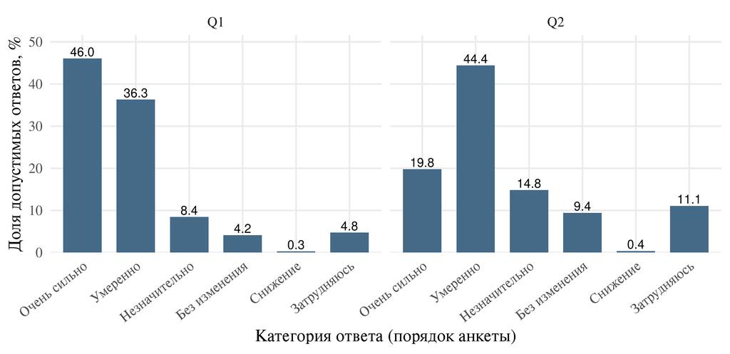

Рисунок 1. Q1/Q2: изменение цен за прошлый и следующий месяц, % ответов.

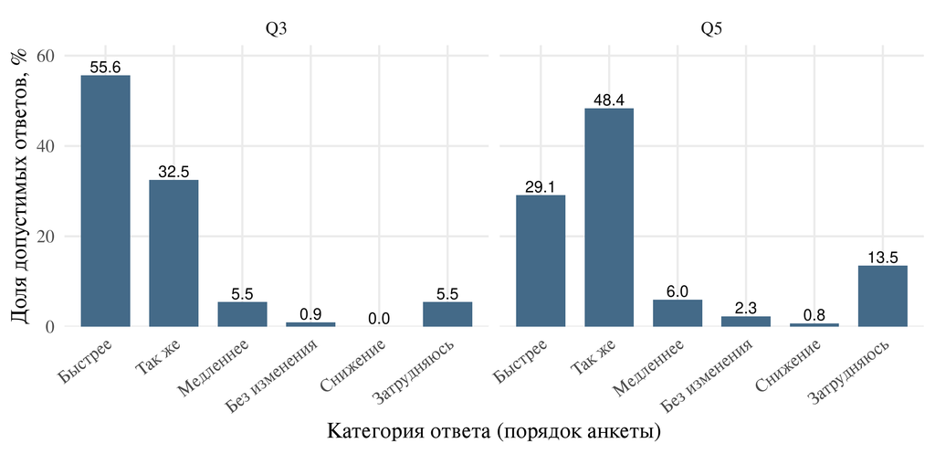

Рисунок 2. Q3/Q5: изменение цен за прошлый и следующий год, % ответов.

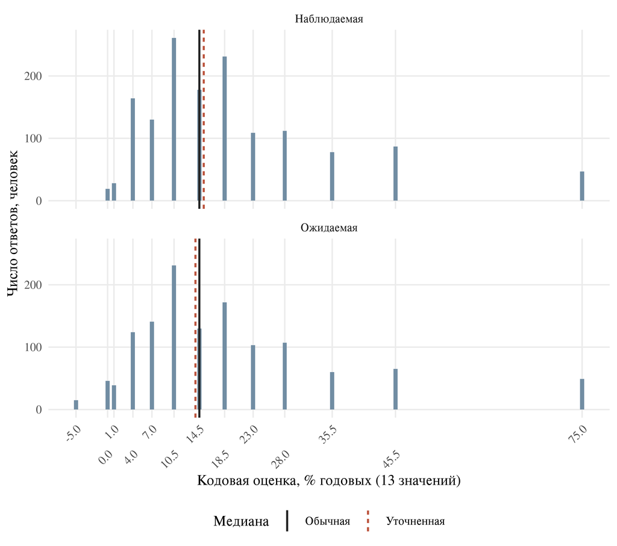

Рисунок 3. Частоты 13 кодов инфляции; обычные и уточненные медианы.

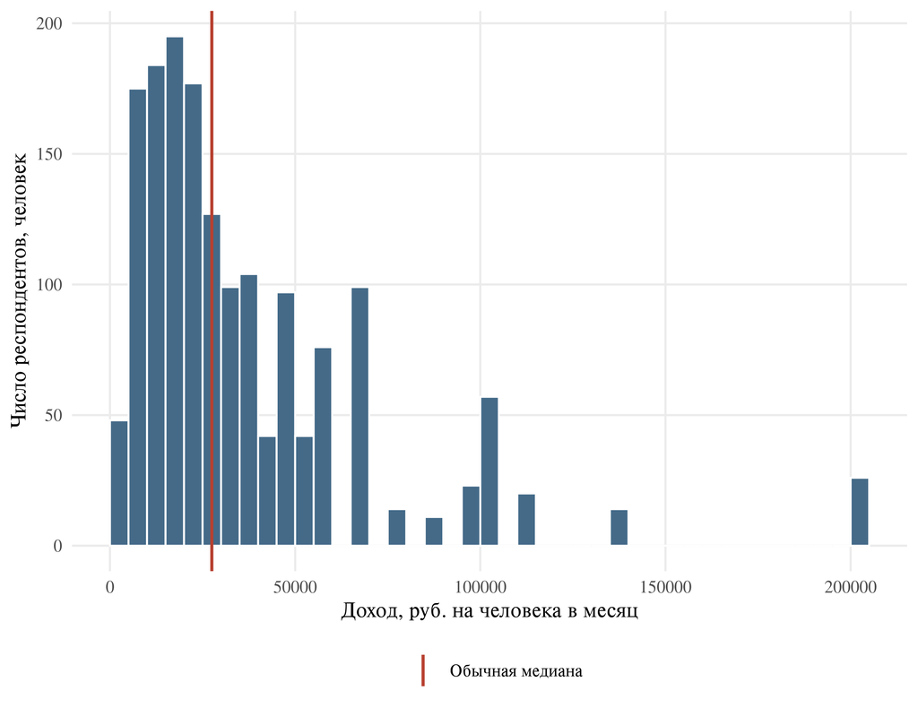

Рисунок 4. Среднедушевой доход: шаг 5000 руб.; линия — обычная медиана.

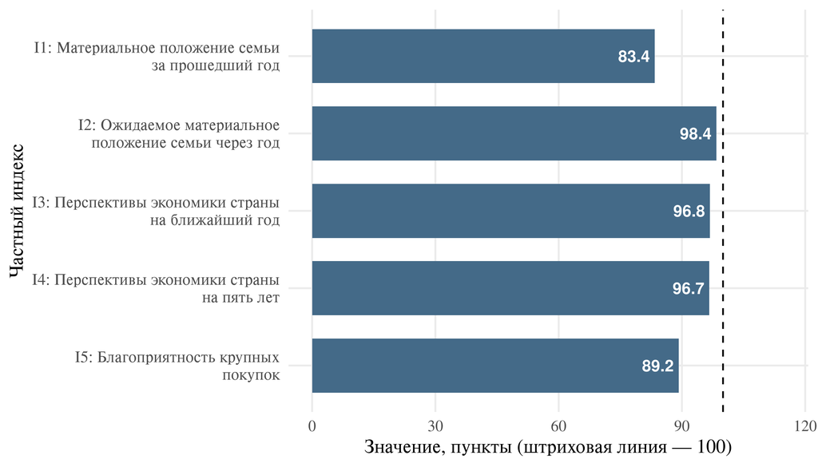

Рисунок 5. Частные индексы I1–I5, пункты; штриховая линия — 100.

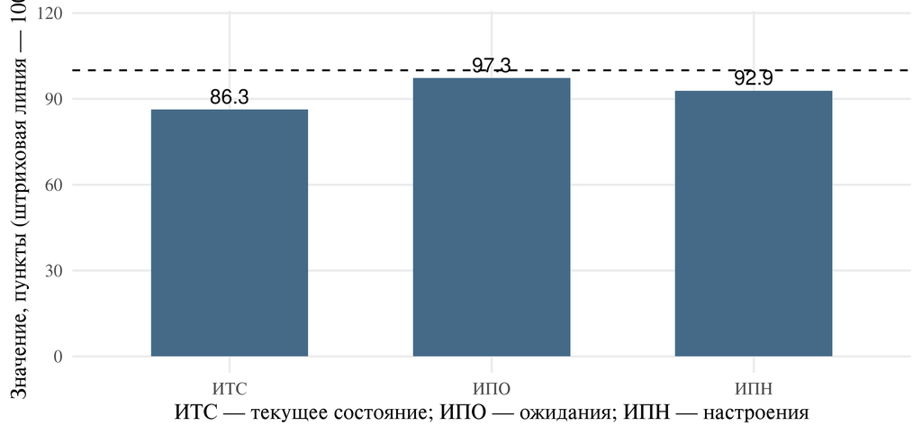

Рисунок 6. ИТС, ИПО и ИПН, пункты; штриховая линия — 100.

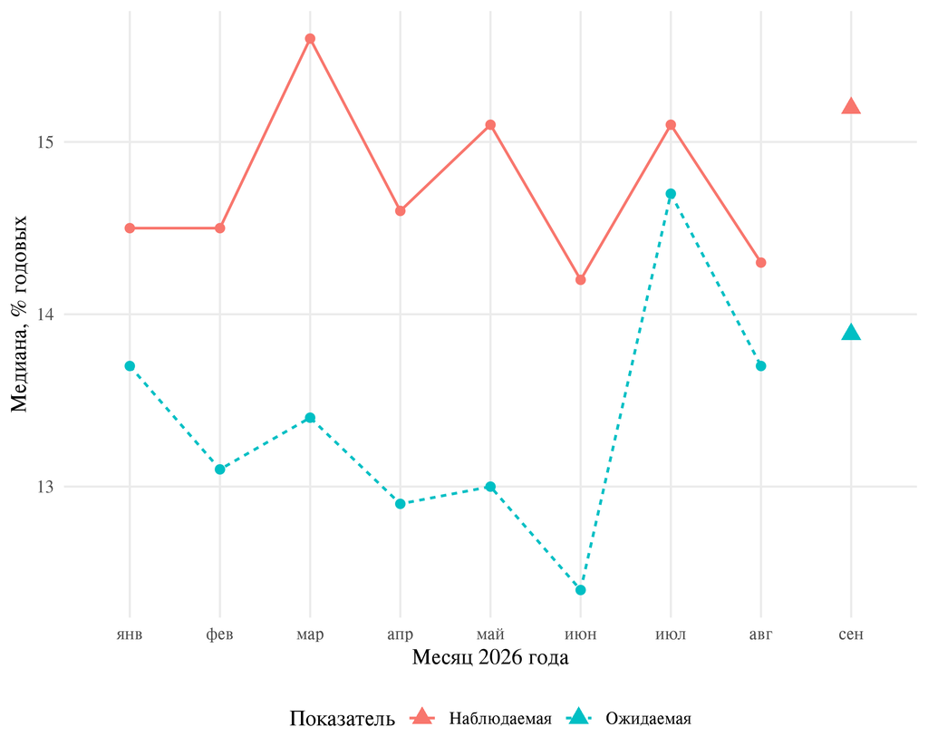

Рисунок 7. Инфляционные медианы: линии — опубликованный январь–август; треугольники — учебный сентябрь.

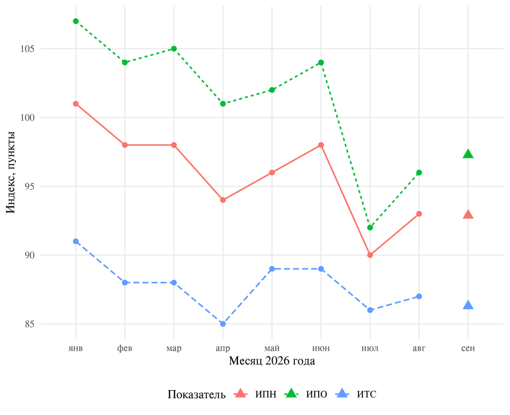

Рисунок 8. ИТС, ИПО, ИПН: линии — опубликованный январь–август; треугольники — учебный сентябрь.

# 8. Динамика и выводы

История — числовые подписи рис. 6 и 12 отчета инФОМ за август 2026, с. 10 и 14. Проверено 18.10.2026. Точность: медианы — 0,1 п. п., индексы — 1 пункт. В таблице «инФОМ» — опубликованный ряд, «Учебн.» — синтетическая выборка.

Таблица 30. Помесячные уровни и источник

| Месяц | Набл., % | Ожид., % | ИТС | ИПО | ИПН | Источник |
| --- | --- | --- | --- | --- | --- | --- |
| янв | 14.5 | 13.7 | 91.0 | 107.0 | 101.0 | инФОМ |
| фев | 14.5 | 13.1 | 88.0 | 104.0 | 98.0 | инФОМ |
| мар | 15.6 | 13.4 | 88.0 | 105.0 | 98.0 | инФОМ |
| апр | 14.6 | 12.9 | 85.0 | 101.0 | 94.0 | инФОМ |
| май | 15.1 | 13.0 | 89.0 | 102.0 | 96.0 | инФОМ |
| июн | 14.2 | 12.4 | 89.0 | 104.0 | 98.0 | инФОМ |
| июл | 15.1 | 14.7 | 86.0 | 92.0 | 90.0 | инФОМ |
| авг | 14.3 | 13.7 | 87.0 | 96.0 | 93.0 | инФОМ |
| сен | 15.2 | 13.9 | 86.3 | 97.3 | 92.9 | Учебн. |

Таблица 31. Август → учебный сентябрь: разность уровней

| Показатель | Август | Сентябрь | Разность | Единица |
| --- | --- | --- | --- | --- |
| Наблюдаемая медиана | 14.3 | 15.2 | 0.9 | п. п. |
| Ожидаемая медиана | 13.7 | 13.9 | 0.2 | п. п. |
| ИТС | 87.0 | 86.3 | -0.7 | пункты |
| ИПО | 96.0 | 97.3 | 1.3 | пункты |
| ИПН | 93.0 | 92.9 | -0.1 | пункты |

Наблюдаемая медиана — 15,2%, ожидаемая — 13,9%; обычные медианы — 14,5% и 14,5%. Различие уточненных оценок связано с интерполяцией внутри интервала.

ИТС = 86,3, ИПО = 97,3, ИПН = 92,9 пункта; все ниже 100. Изменения к августу: инфляционные медианы +0,9 и +0,2 п. п.; ИТС -0,7, ИПО +1,3, ИПН -0,1 пункта. Направления изменений ИТС и ИПО различаются.

Доход рассчитан по 1630 анкетам; обычная медиана 27500,0 руб., уточненная 26417,3 руб. Пропуски исключались отдельно по каждому показателю; группировка влияет на уточненные оценки.

**Различия между опубликованным августом и синтетическим сентябрем нельзя трактовать как реальный сдвиг настроений населения или статистически установленное изменение.**

# Библиография

1. Методические указания к ЛР №1 «Обработка анкет и описательная статистика в R». НИЯУ МИФИ, 2026.
2. Индивидуальный файл Andreus_Aglaya_Ashotovna_B24-902_Var85.xlsx, вариант 85, 2000 анкет.
3. ООО «инФОМ». Измерение инфляционных ожиданий и потребительских настроений. Август 2026, волна 162. С. 10, 14, 20, 74–78. Предоставленный PDF, проверен 18.10.2026. https://www.cbr.ru/Collection/Collection/File/62282/inFOM_26-08.pdf.
4. Учебные материалы по R: ilovepdf_merged_merged.pdf.